# Eugene

Energy in Sport

March 02 2026

## Energy & Training

Homeostasis

- optimum temperature
- optimum pH
- optimal glucose levels
- etc

Adaptations

- overload principle
- specificity
- reversibility
- individuality

## Calorimetry

- Direct: measure heat produced during exercise - Human Calorimetry Chamber
- Indirect: measure O<sub>2</sub> consumption (VO<sub>2</sub>) typically about 0.25mL/kg/s of VO<sub>2</sub> during exercise 0.05mL/kg/s of VO<sub>2</sub> during rest
- Maximum VO<sub>2</sub> measured by exercising to exhaustion get up to 1mL/kg/s
- corresponds to about 250 Watts of power
- training will increase your VO<sub>2</sub> max
- cardiovascular adaptations giving better O<sub>2</sub> delivery
- muscle mitocondrial O<sub>2</sub> utilisation
- athletes using large muscle masses for extended periods tend to have highest VO<sub>2</sub> max

## Respiratory Exchange Ratio (RER)

as well as measuring O<sub>2</sub> levels we also monitor CO<sub>2</sub> gives us the RER
$$RER =
\frac{V_{CO_2}}{V_{O_2}}$$
This gives information on type of food being used

- for fats, RER = 0.7
- for glucose, RER = 1.0

Fats, e.g. palmitate, C<sub>16</sub>H<sub>32</sub>O<sub>2</sub> + 23 O<sub>2</sub> -> 16 CO<sub>2</sub> + 16 H<sub>2</sub>O
$$\frac{16}{23} = 0.70$$
Glucose, C<sub>6</sub>H<sub>12</sub>O<sub>6</sub> + 6 O<sub>2</sub> -> 6 CO<sub>2</sub> + 6 H<sub>2</sub>O
$$\frac{6}{6} = 1.0$$

## Fuel depends on Type of Exercise

- for long distance, endurance, RER lets us deduce that mostly fats are burned
- for high-powered activities like sprinting, mostly carbohydrates

## Fuel used During a Marathon

- muscle triglycerides: provide ~ 30% of energy initially but fades to ~10% gradually over four hours
- plasma FFA: provide ~ 20% initially but this grows to 50% over four hours
- blood glucose: provides 10% initially, this grows to 40% after four hours
- muscle glycogen: provides ~ 40% initially but fades out over about 3 hours
- decrease in CHO use leads to a decrease inperformance and to the onset of fatigue

See [this video](https://www.youtube.com/embed/HDG4GSypcIE) for a discussion of energy use in sled dogs.

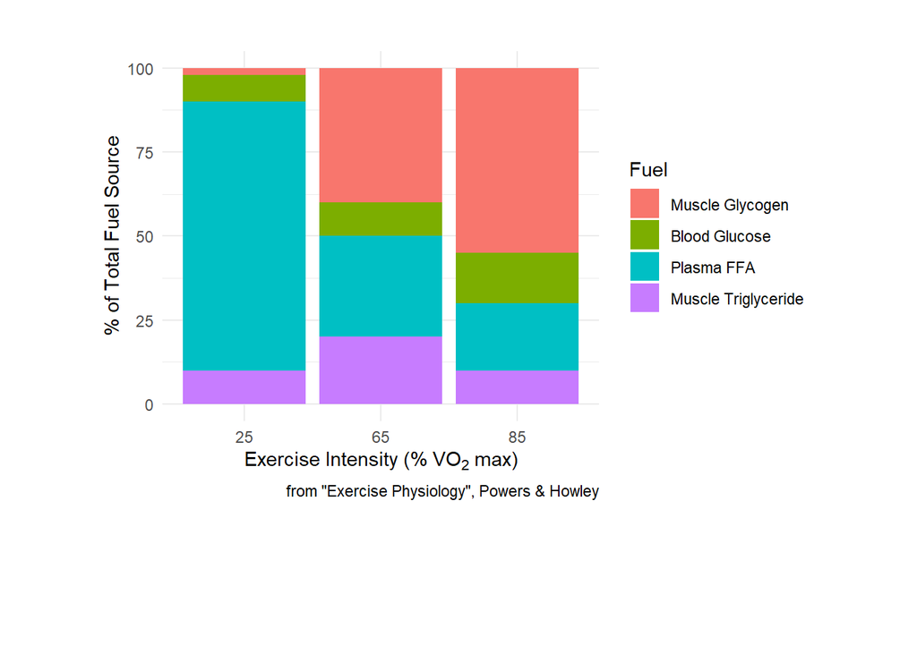

## Crossover Concept

As exercise intensity increases

- progressive **decrease** in **fats** as fuel source
- progressive **increase** in **CHO** as fuel source

Training adaptation - push this crossover point to higher intensities

Leads to sparing of precious CHO stores

Pushes back onset of fatigue

## ATP & Muscle Work

Only ATP can be used to directly cause muscle contraction

- Breakdown of ATP allows crossbridge formation between actin and myosin (enzyme ATPase)
- Amount of ATP in muscle is extremely low
- During exercise as ATP utilisation goes up, need to replace it

$$ATP_{prod} = ATP_{util}$$
ATP producing pathways turns on by the *energy charge* in the cell
$$Energy\; Charge = \frac{[ATP] + {1\over2}
[ADP]}{[ATP] + [ADP] + [AMP]}$$
At rest, the *energy charge* in muscle is about 0.85 As *energy charge* decreases, ATP producing pathways are turned on while ATP utilising pathways are turned off

## Mitochondria

Oxidative production of ATP occurs in mitochondria.

This is vast majority of ATP production.

- Aerobic activity
- Last minutes or longer

## Anaerobic Sources of Energy

Activities lasting seconds need energy immediately Access stores of ATP in the cell

$$ATP + H_2O\; \rightarrow\;ADP + P_i
\qquad ATP_{ase}$$

$$CP + ADP\; \rightarrow \; ATP + C
\qquad creatine\; kinase$$
No O<sub>2</sub> in either process

## Carbohydrates

Carbohydrate can be broken down anaerobically

$$C_6H_{12}O_6\; \rightarrow\; 2 ATP + 2\;
lactate$$
Or aerobically

$$C_6H_{12}O_6 + 6O_2\; \rightarrow\;
30ATP + 6CO_2 + 6H_2O$$
(note, for the same glucose molecule we get 15 times more ATP when broken aerobically) Limited amount of carbohydrate in the body, aerobic metabolism helps preserves carbohydrate stores.

Fats can also be broken down aerobically
$$Palmitate + 23O_2\;\rightarrow\;108ATP +
16CO_2$$

## Carbohydrate Storage

Carbohydrates stored as *Glycogen*

Glycogen = strings of glucose attached to each other

When glucose needed, peeled off from glycogen

Muscle Glycogen

Liver Glycogen

- typically 100g = 400kCal
- needed to maintain blood glucose levels

Blood

- typically 3g = 12kCal (i.e. not very much)

Total of 2000kCal can be depleted during endurance exercise

## Compare to Fat Storage

Adipose Tissue

- typically 12kg = 108,000kCal
- fifty times more energy than carbohydrates
- key aerobic training adaptation is being able to use fat stores
- this preserves carbohydrate stores

## To What Extent do we use Carbohydrates?

- **Intensity and duration of exercise**
- at low intensities use fats
- at high intensities use carbohydrates
- at high intensities use mostly type II muscle fibres
- Type of activity
- Nutritional status

## Different Muscle Fibres

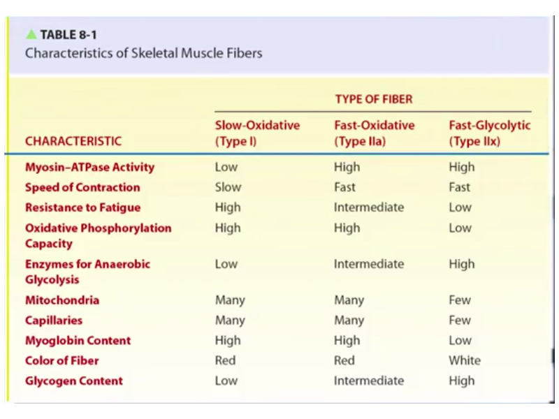

Muscle Fibres

- Training level

## Liver Glycogen

- provides glucose for blood glucose levels
- necessary to avoid exercise induced hypoglycemia
- muscle uptake from blood is up to 50mM/min

## Carbohydrate Loading

- increase CHO content in muscles prior to exercise
- can get up to 250 mM/kg of muscle
- (compare to 90 mM/kg normally)
- increase CHO intake in week prior to exercise
- roughly double it to ~0.6kg/day
- rest for day or so before exercise

## Carbohydrate Feeding

- consumption of very dilute CHO drink during exercise
- athletes at 70 VO<sub>2</sub> max can exercise for ~4 hours rather than 3 hours before fatigue
- gives addition source of CHO thus sparing liver glycogen

## Training Adaptations

- sedentary individuals can double their cell mitochondrial content through training
- takes several weeks
- means using more CHO aerobically rather than anaerobically
- as we’ve seen, this is more more efficient
- spares muscle CHO content
- also observe a lower **RER** for individuals after training
- lower RER means greater fat usage
- this happens at all VO<sub>2</sub> % levels